# Iris

[output not shown]

## O Danych

Zbiór danych zawiera informacje o trzech gatunkach irysów: Iris setosa, Iris versicolor, i Iris virginica.

Dane obejmują pomiary czterech cech: długość i szerokość działki kielicha oraz długość i szerokość płatka.

Każdy wiersz w zbiorze danych reprezentuje pojedynczy kwiat, a wartości pomiarów są podane w centymetrach.

Zbiór składa się z 150 próbek, po 50 dla każdego gatunku, i jest szeroko stosowany jako podstawowy zbiór danych do testowania algorytmów klasyfikacji oraz w nauce o danych i uczeniu maszynowym.

Kolumny:

- **długość kielicha (sepal length)** - Długość kielicha w cm
- **szerokość kielicha (sepal width)** - Szerokość kielicha w cm
- **długość płatka (petal length)** - Długość płatka w cm
- **szerokość płatka (petal width)** - Szerokość płatka w cm
- **klasa (class)** - Klasa irysa (setosa, versicolor, virginica)

|  | długość kielicha (sepal length) | szerokość kielicha (sepal width) | długość płatka (petal length) | szerokość płatka (petal width) | klasa (class) |
| --- | --- | --- | --- | --- | --- |
| 0 | 5.1 | 3.5 | 1.4 | 0.2 | Iris-setosa |
| 1 | 4.9 | 3.0 | 1.4 | 0.2 | Iris-setosa |
| 2 | 4.7 | 3.2 | 1.3 | 0.2 | Iris-setosa |
| 3 | 4.6 | 3.1 | 1.5 | 0.2 | Iris-setosa |
| 4 | 5.0 | 3.6 | 1.4 | 0.2 | Iris-setosa |
| ... | ... | ... | ... | ... | ... |
| 145 | 6.7 | 3.0 | 5.2 | 2.3 | Iris-virginica |
| 146 | 6.3 | 2.5 | 5.0 | 1.9 | Iris-virginica |
| 147 | 6.5 | 3.0 | 5.2 | 2.0 | Iris-virginica |
| 148 | 6.2 | 3.4 | 5.4 | 2.3 | Iris-virginica |
| 149 | 5.9 | 3.0 | 5.1 | 1.8 | Iris-virginica |

150 rows × 5 columns

# Analiza danych dotyczących Irysów (Iris-setosa, Iris-virginica i Iris-versicolor)

## Najpierw poznajmy domene, czyli z czym mamy do czynienia?

### Przedmiotem analizy beda 3 klasy kwiatow Iris:

[figure not shown]

## *Iris setosa*

[figure not shown]

## *Iris Versicolor*

[figure not shown]

## *Iris Virginica*

### *Kosaciec, irys (Iris L.) – rodzaj roślin należący do rodziny kosaćcowatych. Obejmuje co najmniej 311 gatunków. Zasięg rodzaju obejmuje wszystkie kontynenty na półkuli północnej, najbardziej zróżnicowany jest tu w strefie umiarkowanej. Najdalej na południe sięga północnego Meksyku, Jemenu i Filipin.*

[figure not shown]

## 1. Analiza wstepna

|  | długość kielicha (sepal length) | szerokość kielicha (sepal width) | długość płatka (petal length) | szerokość płatka (petal width) | klasa (class) |
| --- | --- | --- | --- | --- | --- |
| 79 | 5.7 | 2.6 | 3.5 | 1.0 | Iris-versicolor |
| 9 | 4.9 | 3.1 | 1.5 | 0.1 | Iris-setosa |
| 137 | 6.4 | 3.1 | 5.5 | 1.8 | Iris-virginica |
| 93 | 5.0 | 2.3 | 3.3 | 1.0 | Iris-versicolor |
| 12 | 4.8 | 3.0 | 1.4 | 0.1 | Iris-setosa |
| 120 | 6.9 | 3.2 | 5.7 | 2.3 | Iris-virginica |
| 2 | 4.7 | 3.2 | 1.3 | 0.2 | Iris-setosa |
| 100 | 6.3 | 3.3 | 6.0 | 2.5 | Iris-virginica |
| 136 | 6.3 | 3.4 | 5.6 | 2.4 | Iris-virginica |
| 71 | 6.1 | 2.8 | 4.0 | 1.3 | Iris-versicolor |

```
długość kielicha (sepal length)     35
szerokość kielicha (sepal width)    23
długość płatka (petal length)       43
szerokość płatka (petal width)      22
klasa (class)                        3
dtype: int64
```

|  | długość kielicha (sepal length) | szerokość kielicha (sepal width) | długość płatka (petal length) | szerokość płatka (petal width) |
| --- | --- | --- | --- | --- |
| count | 150.000000 | 150.000000 | 150.000000 | 150.000000 |
| mean | 5.843333 | 3.054000 | 3.758667 | 1.198667 |
| std | 0.828066 | 0.433594 | 1.764420 | 0.763161 |
| min | 4.300000 | 2.000000 | 1.000000 | 0.100000 |
| 25% | 5.100000 | 2.800000 | 1.600000 | 0.300000 |
| 50% | 5.800000 | 3.000000 | 4.350000 | 1.300000 |
| 75% | 6.400000 | 3.300000 | 5.100000 | 1.800000 |
| max | 7.900000 | 4.400000 | 6.900000 | 2.500000 |

## 2. Analiza brakujacych wartosci :

### Nie ma brakujacych wartosci

```
długość kielicha (sepal length)     0
szerokość kielicha (sepal width)    0
długość płatka (petal length)       0
szerokość płatka (petal width)      0
klasa (class)                       0
dtype: int64
```

## 3. Eksplorujemy poszczegolne kolumny

|  | klasa (class) | długość kielicha (sepal length) mean | długość kielicha (sepal length) median | długość kielicha (sepal length) count | szerokość kielicha (sepal width) mean | szerokość kielicha (sepal width) median | szerokość kielicha (sepal width) count | długość płatka (petal length) mean | długość płatka (petal length) median | długość płatka (petal length) count | szerokość płatka (petal width) mean | szerokość płatka (petal width) median | szerokość płatka (petal width) count |
| --- | --- | --- | --- | --- | --- | --- | --- | --- | --- | --- | --- | --- | --- |
| 0 | Iris-setosa | 5.006 | 5.0 | 50 | 3.418 | 3.4 | 50 | 1.464 | 1.50 | 50 | 0.244 | 0.2 | 50 |
| 1 | Iris-versicolor | 5.936 | 5.9 | 50 | 2.770 | 2.8 | 50 | 4.260 | 4.35 | 50 | 1.326 | 1.3 | 50 |
| 2 | Iris-virginica | 6.588 | 6.5 | 50 | 2.974 | 3.0 | 50 | 5.552 | 5.55 | 50 | 2.026 | 2.0 | 50 |

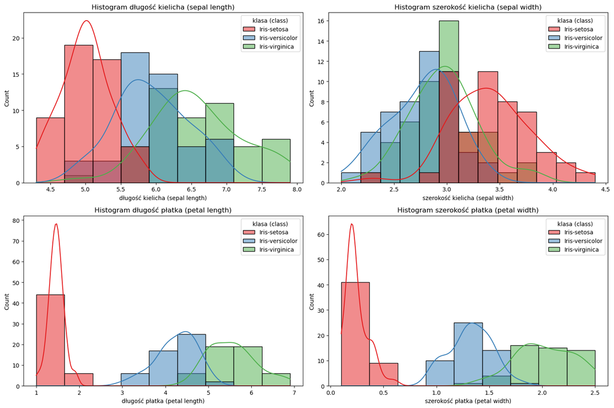

|  | długość kielicha (sepal length) | szerokość kielicha (sepal width) | długość płatka (petal length) | szerokość płatka (petal width) | klasa (class) |
| --- | --- | --- | --- | --- | --- |
| 32 | 5.2 | 4.1 | 1.5 | 0.1 | Iris-setosa |
| 13 | 4.3 | 3.0 | 1.1 | 0.1 | Iris-setosa |
| 37 | 4.9 | 3.1 | 1.5 | 0.1 | Iris-setosa |
| 9 | 4.9 | 3.1 | 1.5 | 0.1 | Iris-setosa |
| 12 | 4.8 | 3.0 | 1.4 | 0.1 | Iris-setosa |
| ... | ... | ... | ... | ... | ... |
| 140 | 6.7 | 3.1 | 5.6 | 2.4 | Iris-virginica |
| 114 | 5.8 | 2.8 | 5.1 | 2.4 | Iris-virginica |
| 100 | 6.3 | 3.3 | 6.0 | 2.5 | Iris-virginica |
| 144 | 6.7 | 3.3 | 5.7 | 2.5 | Iris-virginica |
| 109 | 7.2 | 3.6 | 6.1 | 2.5 | Iris-virginica |

150 rows × 5 columns

## 4. Transformacja danych / naprawa bledow

### *Po posortowaniu wartosci rosnaco, podczas szczegolowej analizy, widze ze krancowe wartosci nie odstaja bardzo od reszty, wiec dochodze do wniosku, ze bledy nie wystepuja*

## 5. Relacje miedzy kolumnami

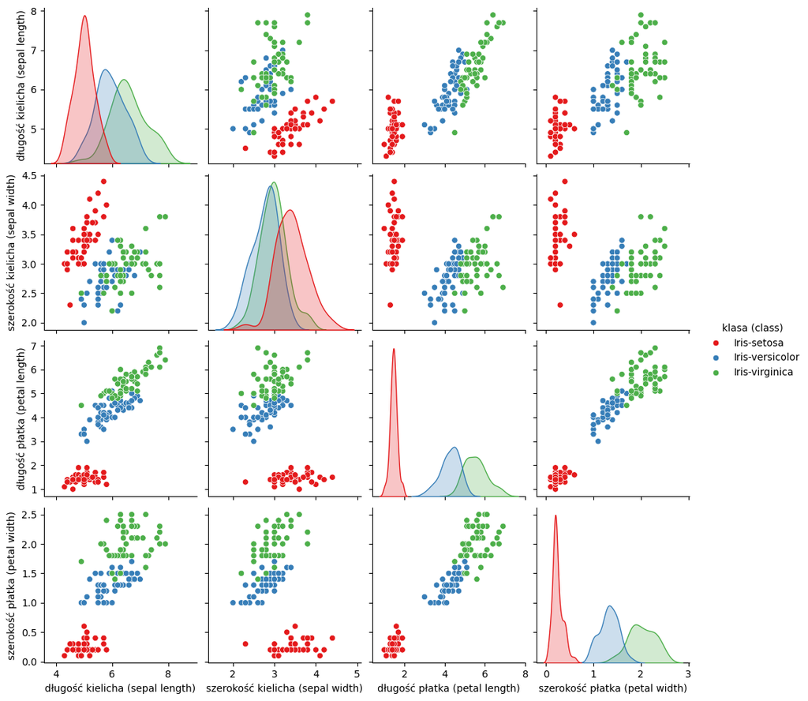

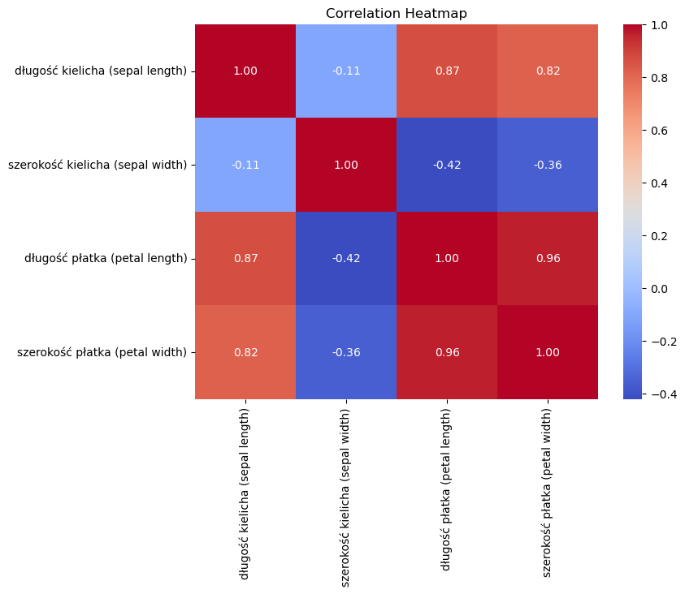

## 6. Analiza wartosci odstajacych

[output not shown]

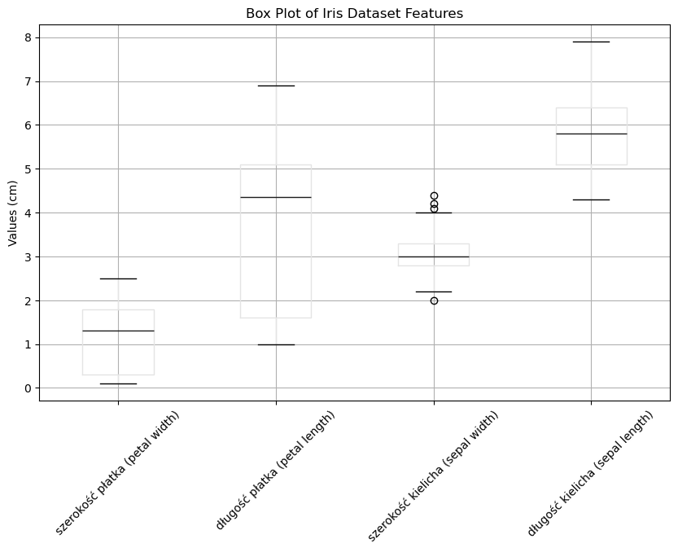

### Analiza wartosci odstajacych wykazuje ze tylko szerokosc kielicha ma kilka wartosci odstajacych, natomiast pozostale wymiary pokazuja duze usrednienie

# Podsumowanie

### 7. Jedynie szerokosc kielicha ma **zaledwie kilka wartosci odstajacych**, natomiast pozostale wymiary pokazuja duze usrednienie